# 2019 CA Population

Savet Hong

2021-03-21

### Overview

In 2019, California total population was about 39.3 million people, and 60.5% of them resided in Southern California (SoCal). In particular, Los Angeles county accounts for 25.7% of the state’s population.

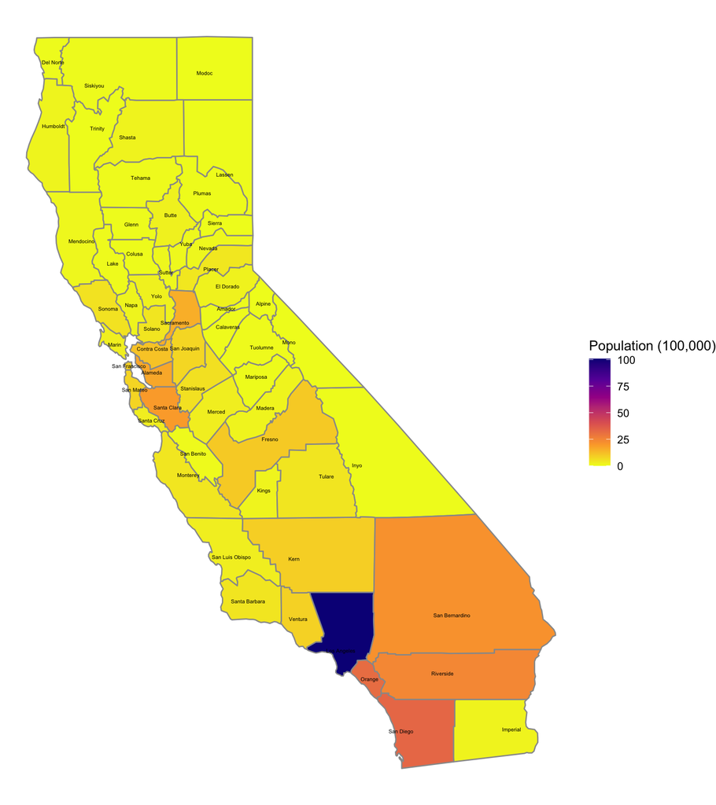

#### Age Distribution of State Population

The population of Southern California is largely comprised of people aged 18-64 (63.5%). This region’s working age adults (18-64) accounts for 60.9% of all working age adults in California (38.4% of entire population). Other areas of the state that have high concentration of working age adults include the Bay Area (20% of age group, 12.6% of state’s population) and Greater Sacramento (6.4% of age group, 4.1% of state’s population).

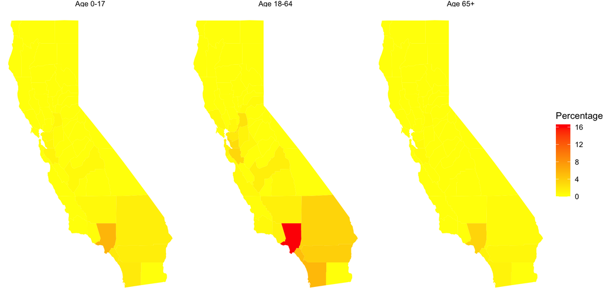

#### Age Distribution Within County

When considering each county’s age population distribution, it is no surprise that each county’s residents are largely working age adults (about 60%). What is interesting is that some counties have a higher share of children, mainly counties in the San Joaquin Valley. Whereas, counties on the northern and eastern parts of California have a higher share of elderly adults.

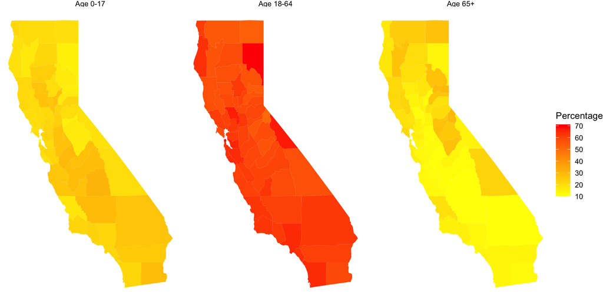